# Missing

Sanghoo Yoon

2019년 10월 8일

- read.csv함수를 통한 데이터 로딩
- head()함수를 이용하여 상위 6개 확인
- names() 함수 변수명 확인
- str() 데이터의 구조 확인

```r
df<-read.csv("F:/work/R-work/2019/KERIS/day4/실습데이터.csv")

head(df)
```

```
##   지점            일시 기온..C. 강수량.mm. 풍속.m.s. 풍향.16방위. 습도...
## 1  108 2018-07-01 1:00     22.7         NA       0.5          110      87
## 2  108 2018-07-01 2:00     22.7         NA       0.5           70      87
## 3  108 2018-07-01 3:00     22.7         NA       0.7          110      86
## 4  108 2018-07-01 4:00     22.7         NA       0.7           70      85
## 5  108 2018-07-01 5:00     22.6        0.1       0.5           70      86
## 6  108 2018-07-01 6:00     22.3        0.4       0.6          140      93
##   전운량.10분위.
## 1             NA
## 2             NA
## 3              9
## 4             10
## 5             10
## 6             10
```

```r
#변수명 확인

#변수명 새로운 이름으로 할당
names(df)<-c("loc","date","temp","rain","ws","wd","humidity","cloud")

#구조 확인
str(df)
```

```
## 'data.frame':    2232 obs. of  8 variables:
##  $ loc     : int  108 108 108 108 108 108 108 108 108 108 ...
##  $ date    : Factor w/ 744 levels "2018-07-01 1:00",..: 1 12 17 18 19 20 21 22 23 2 ...
##  $ temp    : num  22.7 22.7 22.7 22.7 22.6 22.3 22.1 22.1 22.1 21.6 ...
##  $ rain    : num  NA NA NA NA 0.1 0.4 0.5 1 1.5 12 ...
##  $ ws      : num  0.5 0.5 0.7 0.7 0.5 0.6 0.5 0.5 0.9 0.5 ...
##  $ wd      : int  110 70 110 70 70 140 110 110 50 140 ...
##  $ humidity: int  87 87 86 85 86 93 89 93 94 97 ...
##  $ cloud   : int  NA NA 9 10 10 10 10 10 10 10 ...
```

```r
#데이터 형태의 변경
df$loc<-as.factor(df$loc)
df$date<-as.Date(df$date)
df$wd<-as.factor(df$wd)
df$cloud<-as.factor(df$cloud)
```

- 자료에 결측치가 있는지 확인하기 위해선 is.na()함수를 사용하자.
- 결측치가 자료의 10% 미만인 경우에는 결측치를 제거한 데이터로 자료를 분석한다.
- 만약 결측치가 10~40% 된다면?? imputation 방법을 통해 결측치를 대체하여 분석한다.

```r
#NA(Not available);결측인지 아닌지 확인
head(is.na(df))
```

```
##        loc  date  temp  rain    ws    wd humidity cloud
## [1,] FALSE FALSE FALSE  TRUE FALSE FALSE    FALSE  TRUE
## [2,] FALSE FALSE FALSE  TRUE FALSE FALSE    FALSE  TRUE
## [3,] FALSE FALSE FALSE  TRUE FALSE FALSE    FALSE FALSE
## [4,] FALSE FALSE FALSE  TRUE FALSE FALSE    FALSE FALSE
## [5,] FALSE FALSE FALSE FALSE FALSE FALSE    FALSE FALSE
## [6,] FALSE FALSE FALSE FALSE FALSE FALSE    FALSE FALSE
```

```r
#R에서는 TRUE에 해당하는 값만 추출
#!는 not의 의미

#데이터중 전운량이 결측이 아닌값만 추출
head(df[!is.na(df$cloud),])
```

```
##   loc       date temp rain  ws  wd humidity cloud
## 3 108 2018-07-01 22.7   NA 0.7 110       86     9
## 4 108 2018-07-01 22.7   NA 0.7  70       85    10
## 5 108 2018-07-01 22.6  0.1 0.5  70       86    10
## 6 108 2018-07-01 22.3  0.4 0.6 140       93    10
## 7 108 2018-07-01 22.1  0.5 0.5 110       89    10
## 8 108 2018-07-01 22.1  1.0 0.5 110       93    10
```

```r
#complete.cases를 통해 변수중 하나라도 결측이 아닌값들만 추출
head(df[complete.cases(df),])
```

```
##    loc       date temp rain  ws  wd humidity cloud
## 5  108 2018-07-01 22.6  0.1 0.5  70       86    10
## 6  108 2018-07-01 22.3  0.4 0.6 140       93    10
## 7  108 2018-07-01 22.1  0.5 0.5 110       89    10
## 8  108 2018-07-01 22.1  1.0 0.5 110       93    10
## 9  108 2018-07-01 22.1  1.5 0.9  50       94    10
## 10 108 2018-07-01 21.6 12.0 0.5 140       97    10
```

- []대괄호는 자료의 index 즉 순서를 의미한다. 자료가 data.frame의 구조라면 [행,열]을 선택하면 된다.

즉, df[!is.na(df$cloud),]는 df %>% filter(!is.na(cloud))와 같다.

- 결측치가 제거된 자료를 사용하고자 하는 경우에는 결과를 data2<-df[!is.na(df$cloud),] 처럼 꼭 할당해두자.
- 이 외 시각적인 방법을 통해 이상치를 발견하는 방법은?

```r
library(mice)
library(VIM)
```

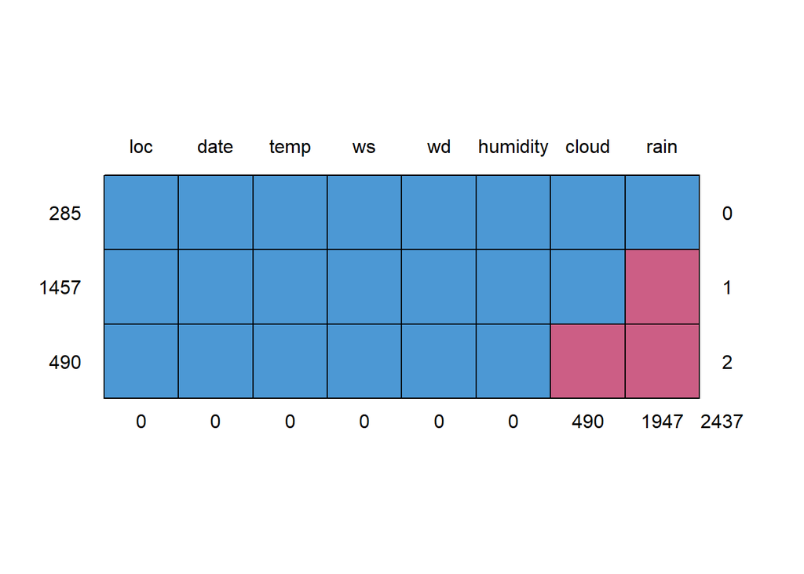

```
##      loc date temp ws wd humidity cloud rain
## 285    1    1    1  1  1        1     1    1    0
## 1457   1    1    1  1  1        1     1    0    1
## 490    1    1    1  1  1        1     0    0    2
##        0    0    0  0  0        0   490 1947 2437
```

```r
#결측의 패턴을 표로 확인
md.pattern(df)
```

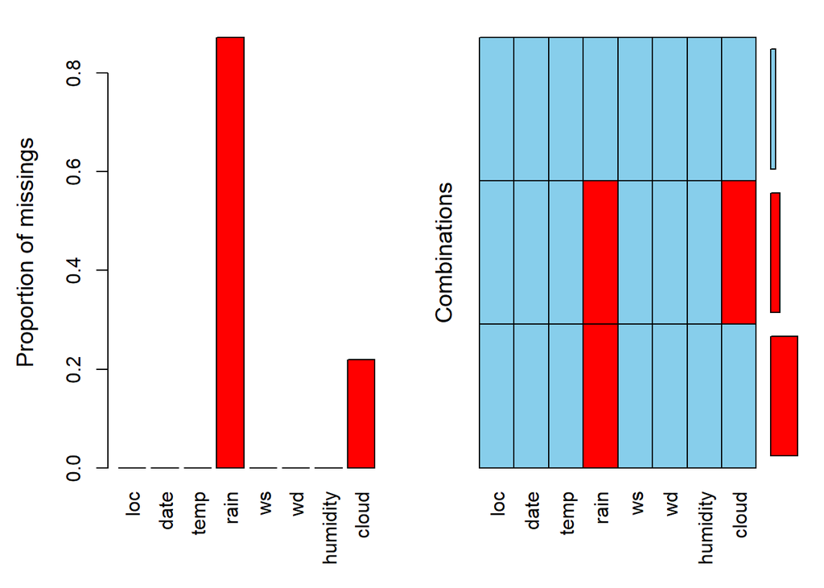

```r
#결측의 패턴을 시각화로 확인
aggr(df)
```

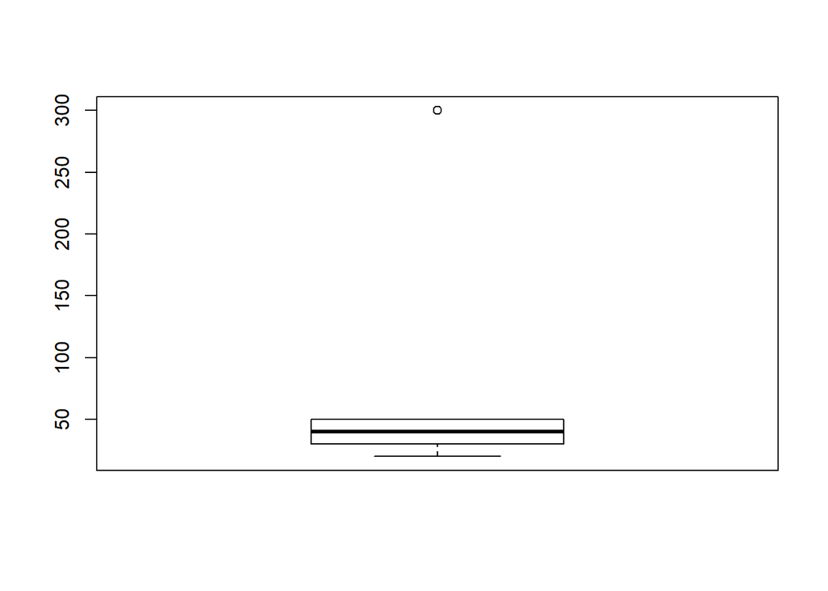

```r
#이상치 있는 데이터 생성(temp 300)
df2<-data.frame(id=c(1,2,3,4,5), temp=c(20,30,40,50,300))

#시각화를 통한 이상치의 발견
boxplot(df2$temp)
```

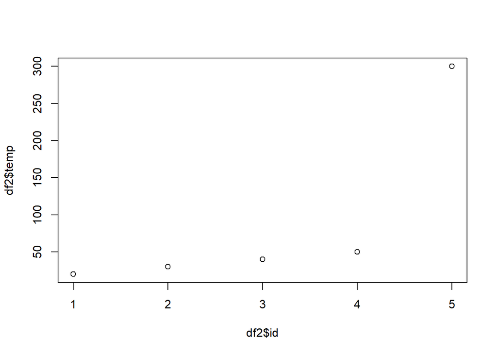

```r
plot(df2$id, df2$temp)
```

이제 knn방법을 통해 결측치를 보정하는 방법을 알아보자.

iris 자료를 불러와 NA를 추가시켜보자.

```r
iris_na <- iris
iris_na[c(10, 20, 25, 40, 32), 3] <- NA
iris_na[c(33, 100, 123), 1] <- NA
iris_na[!complete.cases(iris_na), ]
```

```
##     Sepal.Length Sepal.Width Petal.Length Petal.Width    Species
## 10           4.9         3.1           NA         0.1     setosa
## 20           5.1         3.8           NA         0.3     setosa
## 25           4.8         3.4           NA         0.2     setosa
## 32           5.4         3.4           NA         0.4     setosa
## 33            NA         4.1          1.5         0.1     setosa
## 40           5.1         3.4           NA         0.2     setosa
## 100           NA         2.8          4.1         1.3 versicolor
## 123           NA         2.8          6.7         2.0  virginica
```

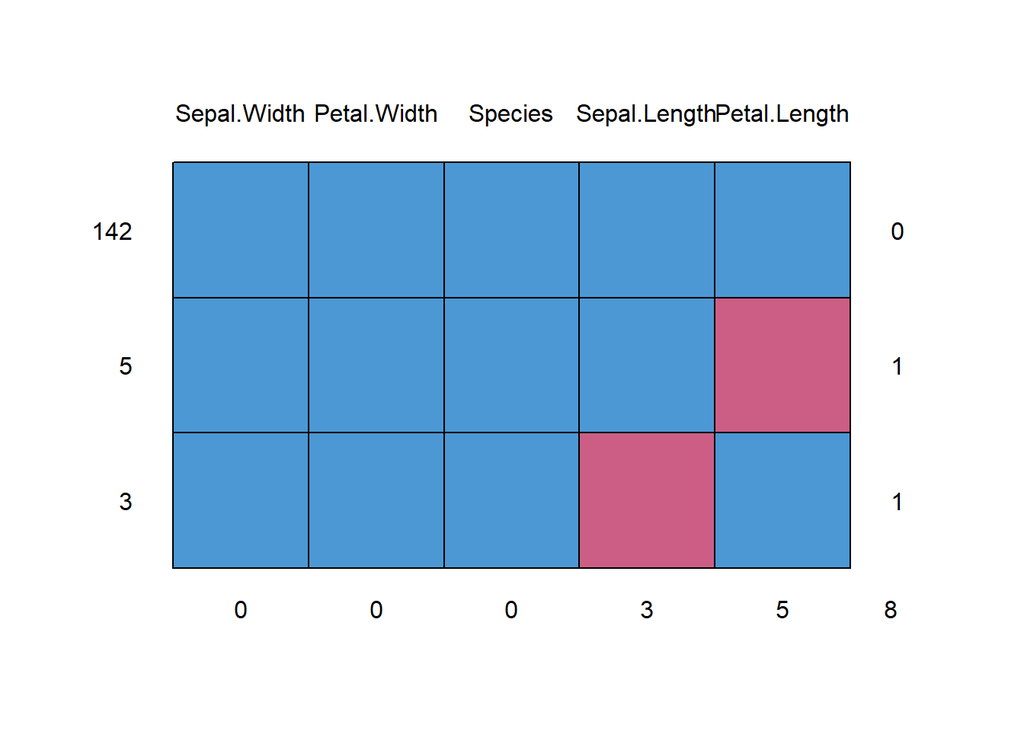

```
##     Sepal.Width Petal.Width Species Sepal.Length Petal.Length
## 142           1           1       1            1            1 0
## 5             1           1       1            1            0 1
## 3             1           1       1            0            1 1
##               0           0       0            3            5 8
```

```r
md.pattern(iris_na)
```

이제 중앙값을 찾아보자. 평균값으로 대체 해도 된다.

```r
median(iris_na[,1], na.rm=T)
```

```
## [1] 5.8
```

```r
median(iris_na[,2], na.rm=T)
```

```
## [1] 3
```

```r
median(iris_na[,3], na.rm=T)
```

```
## [1] 4.4
```

```r
median(iris_na[,4], na.rm=T)
```

```
## [1] 1.3
```

계산된 중앙값을 결측치 값에 직접 입력하면 된다.

여기서 [행,열] : 행에서는 결측치를 선택하고, 열에서는 입력하려는 변수를 입력하자.

```
##  /\     /\
## {  `---'  }
## {  O   O  }
## ==>  V <==  No need for mice. This data set is completely observed.
##  \  \|/  /
##   `-----'
```

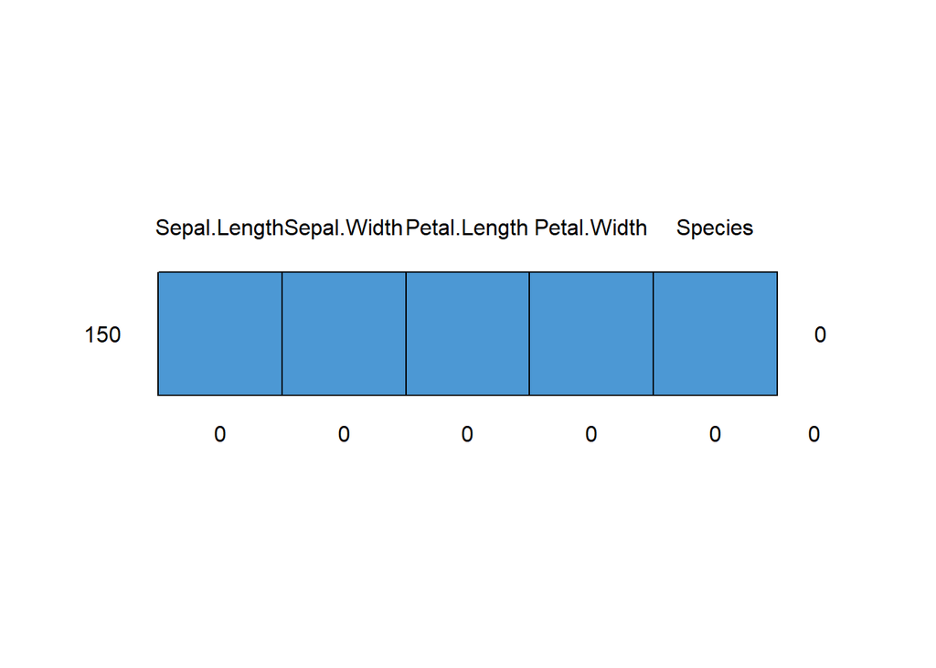

```
##     Sepal.Length Sepal.Width Petal.Length Petal.Width Species
## 150            1           1            1           1       1 0
##                0           0            0           0       0 0
```

```r
iris_na2 <- iris_na

iris_na[is.na(iris_na[,1]),1]=median(iris_na[,1], na.rm=T)
iris_na[is.na(iris_na[,3]),3]=median(iris_na[,3], na.rm=T)

md.pattern(iris_na)
```

DMwR 팩키지를 이용하면 조금 더 쉽게 할 수 있다.

centralImpuation()는 중앙값으로 결측치를 대체하고

이 외에도 여러 방법들이 있다.

```r
library(DMwR)
iris_na2[!complete.cases(iris_na2), ]
```

```
##     Sepal.Length Sepal.Width Petal.Length Petal.Width    Species
## 10           4.9         3.1           NA         0.1     setosa
## 20           5.1         3.8           NA         0.3     setosa
## 25           4.8         3.4           NA         0.2     setosa
## 32           5.4         3.4           NA         0.4     setosa
## 33            NA         4.1          1.5         0.1     setosa
## 40           5.1         3.4           NA         0.2     setosa
## 100           NA         2.8          4.1         1.3 versicolor
## 123           NA         2.8          6.7         2.0  virginica
```

```r
iris_na[!complete.cases(iris_na), ]
```

```
## [1] Sepal.Length Sepal.Width  Petal.Length Petal.Width  Species
## <0 rows> (or 0-length row.names)
```

```r
which(!complete.cases(iris_na2))
```

```
## [1]  10  20  25  32  33  40 100 123
```

```r
centralImputation(iris_na2[1:4]) # 결측치를 중앙값으로 대체
```

```
##     Sepal.Length Sepal.Width Petal.Length Petal.Width
## 1            5.1         3.5          1.4         0.2
## 2            4.9         3.0          1.4         0.2
## 3            4.7         3.2          1.3         0.2
## 4            4.6         3.1          1.5         0.2
## 5            5.0         3.6          1.4         0.2
## 6            5.4         3.9          1.7         0.4
## 7            4.6         3.4          1.4         0.3
## 8            5.0         3.4          1.5         0.2
## 9            4.4         2.9          1.4         0.2
## 10           4.9         3.1          4.4         0.1
## 11           5.4         3.7          1.5         0.2
## 12           4.8         3.4          1.6         0.2
## 13           4.8         3.0          1.4         0.1
## 14           4.3         3.0          1.1         0.1
```

[output cut: 136 more lines]

```r
centralImputation(iris_na2[1:4])[which(!complete.cases(iris_na2)), ] # 결측치만 선택하여 확인
```

```
##     Sepal.Length Sepal.Width Petal.Length Petal.Width
## 10           4.9         3.1          4.4         0.1
## 20           5.1         3.8          4.4         0.3
## 25           4.8         3.4          4.4         0.2
## 32           5.4         3.4          4.4         0.4
## 33           5.8         4.1          1.5         0.1
## 40           5.1         3.4          4.4         0.2
## 100          5.8         2.8          4.1         1.3
## 123          5.8         2.8          6.7         2.0
```

```r
knnImputation(iris_na[1:4])[which(!complete.cases(iris_na2)), ]
```

```
##     Sepal.Length Sepal.Width Petal.Length Petal.Width
## 10           4.9         3.1          4.4         0.1
## 20           5.1         3.8          4.4         0.3
## 25           4.8         3.4          4.4         0.2
## 32           5.4         3.4          4.4         0.4
## 33           5.8         4.1          1.5         0.1
## 40           5.1         3.4          4.4         0.2
## 100          5.8         2.8          4.1         1.3
## 123          5.8         2.8          6.7         2.0
```